# Projekt zaliczeniowy na zajęcia Przetwarzanie i analiza danych w języku Python - Jakub Niedziela - 412466

Celem głównym niniejszego projektu jest analiza wpływu różnych czynników na ilość przestępstw w kraju.

Celem pobocznym jest zaliczenie zajęć "Przetwarzanie i analiza danych w języku Python".

##### Hipotezy badawcze:

- H1: Powszechne prawo dostępu do broni wpływa na liczbę przestępstw w kraju.
- H2: Obecna w prawie kara śmierci obniża liczbę przestępstw w kraju.
- H3: Ilość spożywanego alkoholu przez społeczeństwo dodatnio wpływa na liczbę przestępstw w kraju.
- H4: Poziom bezrobocia wpływa dodatnio na liczbę przestępstw w kraju.
- H5: Lepsza edukacja w kraju wpływa ujemnie na liczbę przestępstw w kraju.

# Wczytanie i przetworzenie danych

Dane pochodzą z różnych źródeł:

- GDP per capita - https://data.worldbank.org/indicator/NY.GDP.PCAP.KD?end=2019&name_desc=false&start=1991
- Population - https://data.worldbank.org/indicator/SP.POP.TOTL
- EDU - http://hdr.undp.org/en/indicators/103706#
- Crime - https://www.numbeo.com/crime/rankings_current.jsp
- Unemployment - https://data.worldbank.org/indicator/SL.UEM.TOTL.ZS
- Alcohol - https://www.who.int/data/gho/data/indicators/indicator-details/GHO/alcohol-recorded-per-capita-(15-)-consumption-(in-litres-of-pure-alcohol)
- Death - https://www.amnesty.org/en/what-we-do/death-penalty/
- Gun - https://www.gunpolicy.org/firearms/compare/16/right_to_possess_firearms

Dane zostały wklejone do excela po czym dla każdej ze zmiennych zostały wyodrębnione dane za 2015 rok i zostały zapisane w formacie csv.

```python
import pandas as pd
import numpy as np
import matplotlib.pyplot as plt
import seaborn as sns
import statistics as stats
import scipy
```

```python
sns.set()
```

## Wczytanie danych

```python
crime = pd.read_csv('dane_projekt/Crime.csv', sep=';', decimal=',')
crime = crime.dropna()
```

```python
cont = pd.read_csv('dane_projekt/Continents.csv', sep=';', encoding='unicode-escape')
cont = cont.dropna()
```

```python
edu = pd.read_csv('dane_projekt/EDU.csv', sep=';', encoding='unicode-escape')
edu = edu.dropna()
edu['EDU'] = edu['2015']
edu['Country'] = edu['Country'].str.strip()
del edu['2015']
```

```python
gdp = pd.read_csv('dane_projekt/gdp.csv', sep=';', encoding='unicode-escape', decimal=',')
del gdp['Unnamed: 2']
gdp = gdp.dropna()
```

```python
unemployment = pd.read_csv('dane_projekt/Unemployment.csv', sep=';', encoding='unicode-escape', decimal=',')
unemployment = unemployment.dropna()
```

```python
alco = pd.read_csv('dane_projekt/Alcohol.csv', sep=';', encoding='unicode-escape', decimal=',')
alco = alco.dropna()
```

```python
gun = pd.read_csv('dane_projekt/GUN.csv', sep=';', encoding='unicode-escape', decimal=',')
gun = gun.dropna()
```

```python
death = pd.read_csv('dane_projekt/Death.csv', sep=';', encoding='unicode-escape', decimal=',')
death = death.dropna()
```

```python
pop = pd.read_csv('dane_projekt/Population.csv', sep=';', encoding='unicode-escape')
pop = pop.dropna()
pop['pop'] = pop['pop'].astype('int')
```

## Połączenie danych

```python
crime_gdp = crime.merge(gdp, on='Country', how='inner')
```

```python
crime_gdp_unem = crime_gdp.merge(unemployment, on='Country', how='inner')
```

```python
crime_gdp_unem_alco = crime_gdp_unem.merge(alco, on='Country', how='inner')
```

```python
crime_gdp_unem_alco_edu = crime_gdp_unem_alco.merge(edu, on='Country', how='inner')
```

```python
crime_gdp_unem_alco_edu_gun = crime_gdp_unem_alco_edu.merge(gun, on='Country', how='inner')
```

```python
crime_gdp_unem_alco_edu_gun_death = crime_gdp_unem_alco_edu_gun.merge(death, on='Country', how='inner')
```

```python
crime_gdp_unem_alco_edu_gun_death_pop = crime_gdp_unem_alco_edu_gun_death.merge(pop, on='Country', how='inner')
```

```python
crime_gdp_unem_alco_edu_gun_death_pop_cont = crime_gdp_unem_alco_edu_gun_death_pop.merge(cont, on='Country', how='inner')
```

```python
dane = crime_gdp_unem_alco_edu_gun_death_pop_cont
dane.info()
```

```
<class 'pandas.core.frame.DataFrame'>
Int64Index: 114 entries, 0 to 113
Data columns (total 10 columns):
 #   Column        Non-Null Count  Dtype
---  ------        --------------  -----
 0   Country       114 non-null    object
 1   Crime         114 non-null    float64
 2   GDPpc         114 non-null    float64
 3   Unemployment  114 non-null    float64
 4   Alco          114 non-null    float64
 5   EDU           114 non-null    float64
 6   gun           114 non-null    int64
 7   Death         114 non-null    int64
 8   pop           114 non-null    int32
 9   Continent     114 non-null    object
dtypes: float64(5), int32(1), int64(2), object(2)
memory usage: 9.4+ KB
```

## Przetworzenie danych

```python
dane['log(Crime)'] = dane['Crime'].apply(np.log)  # stworzenie logarytmu zmiennej Crime
dane['EDUU'] = dane['EDU'].apply(lambda x: 1/x)  # stworzenie odwrotności zmiennej EDU
dane['pop'] = dane['pop'].astype('int')  # zmiana typu zmiennej Population z float na integer
```

```python
# stworzenie zmiennych zerojedynkowych dla kontynentów
continents = ['Asia', 'Europe', 'Africa', 'North America', 'South America', 'Oceania']

for name in continents:
    dane[name] = dane['Continent'].apply(lambda x: 1 if x==name else 0)

dane['North_America'] = dane['North America']  # zmiana nazwy
dane['South_America'] = dane['South America']  # zmiana nazwy
del dane['North America']
del dane['South America']
```

```python
dane = dane.set_index(dane['Country'])
del dane['Country']
```

```python
dane.info()
```

```
<class 'pandas.core.frame.DataFrame'>
Index: 114 entries, Guatemala to Singapore
Data columns (total 17 columns):
 #   Column         Non-Null Count  Dtype
---  ------         --------------  -----
 0   Crime          114 non-null    float64
 1   GDPpc          114 non-null    float64
 2   Unemployment   114 non-null    float64
 3   Alco           114 non-null    float64
 4   EDU            114 non-null    float64
 5   gun            114 non-null    int64
 6   Death          114 non-null    int64
 7   pop            114 non-null    int32
 8   Continent      114 non-null    object
 9   log(Crime)     114 non-null    float64
 10  EDUU           114 non-null    float64
 11  Asia           114 non-null    int64
 12  Europe         114 non-null    int64
 13  Africa         114 non-null    int64
 14  Oceania        114 non-null    int64
 15  North_America  114 non-null    int64
 16  South_America  114 non-null    int64
dtypes: float64(7), int32(1), int64(8), object(1)
memory usage: 15.6+ KB
```

```python
display(dane.head())
```

| Country | Crime | GDPpc | Unemployment | Alco | EDU | gun | Death | pop | Continent | log(Crime) | EDUU | Asia | Europe | Africa | Oceania | North_America | South_America |
| --- | --- | --- | --- | --- | --- | --- | --- | --- | --- | --- | --- | --- | --- | --- | --- | --- | --- |
| Guatemala | 79.34 | 3210.869670 | 2.506 | 1.640 | 0.512 | 1 | 1 | 15567419 | North America | 4.373742 | 1.953125 | 0 | 0 | 0 | 0 | 1 | 0 |
| South Africa | 78.44 | 7556.788579 | 25.156 | 7.330 | 0.720 | 0 | 0 | 55386367 | Africa | 4.362334 | 1.388889 | 0 | 0 | 1 | 0 | 0 | 0 |
| Afghanistan | 77.34 | 574.184114 | 11.387 | 0.002 | 0.405 | 0 | 1 | 34413603 | Asia | 4.348211 | 2.469136 | 1 | 0 | 0 | 0 | 0 | 0 |
| Guyana | 76.88 | 3688.692257 | 12.004 | 5.940 | 0.598 | 0 | 1 | 767432 | South America | 4.342246 | 1.672241 | 0 | 0 | 0 | 0 | 0 | 1 |
| Nigeria | 76.60 | 2563.148864 | 4.311 | 7.830 | 0.474 | 0 | 1 | 181137448 | Africa | 4.338597 | 2.109705 | 0 | 0 | 1 | 0 | 0 | 0 |

```python
display(dane.tail())
```

| Country | Crime | GDPpc | Unemployment | Alco | EDU | gun | Death | pop | Continent | log(Crime) | EDUU | Asia | Europe | Africa | Oceania | North_America | South_America |
| --- | --- | --- | --- | --- | --- | --- | --- | --- | --- | --- | --- | --- | --- | --- | --- | --- | --- |
| Qatar | 21.04 | 65137.057390 | 0.170 | 1.07 | 0.642 | 0 | 1 | 2565710 | Asia | 3.046425 | 1.557632 | 1 | 0 | 0 | 0 | 0 | 0 |
| Japan | 20.24 | 47102.580880 | 3.400 | 6.85 | 0.839 | 0 | 1 | 127141000 | Asia | 3.007661 | 1.191895 | 1 | 0 | 0 | 0 | 0 | 0 |
| Rwanda | 19.16 | 767.602645 | 1.143 | 7.05 | 0.452 | 0 | 0 | 11369071 | Africa | 2.952825 | 2.212389 | 0 | 0 | 1 | 0 | 0 | 0 |
| Turkmenistan | 17.86 | 6693.932002 | 3.954 | 3.36 | 0.628 | 0 | 0 | 5565287 | Asia | 2.882564 | 1.592357 | 1 | 0 | 0 | 0 | 0 | 0 |
| Singapore | 17.59 | 54009.738920 | 3.790 | 1.82 | 0.835 | 0 | 1 | 5535002 | Asia | 2.867331 | 1.197605 | 1 | 0 | 0 | 0 | 0 | 0 |

```python
zmienne = [['Crime', 'Wskaźnik przestępczości', 'ciągła'],
          ['Alco', 'Średnia ilość spożywanego alkoholu','ciągła'],
          ['Unemployment', 'Wskaźnik bezrobocia','ciągła'],
          ['GDPpc', 'Produkt Krajowy Brutto per capita','ciągła'],
          ['Death', 'Czy kraj stosuje karę śmierci (0/1)','binarna'],
          ['gun', 'Czy dostęp do broni nie wymaga pozwolenia? (0/1)','binarna'],
          ['Continent', 'Nazwy kontynentów','binarna'],
          ['pop', 'Liczba ludności w kraju','ciągła'],
          ['log(crime)', 'logarytm naturalny zmiennej Crime', 'ciągła'],
           ['EDU', 'Wskaźnik poziomu edukacji','ciągła'],
          ['EDUU', 'Odwrotność zmiennej EDU (1/EDU)', 'ciągła']]

display(pd.DataFrame(zmienne, columns=['Zmienna', 'Objaśnienie zmiennej', 'Rodzaj zmiennej']))
```

|  | Zmienna | Objaśnienie zmiennej | Rodzaj zmiennej |
| --- | --- | --- | --- |
| 0 | Crime | Wskaźnik przestępczości | ciągła |
| 1 | Alco | Średnia ilość spożywanego alkoholu | ciągła |
| 2 | Unemployment | Wskaźnik bezrobocia | ciągła |
| 3 | GDPpc | Produkt Krajowy Brutto per capita | ciągła |
| 4 | Death | Czy kraj stosuje karę śmierci (0/1) | binarna |
| 5 | gun | Czy dostęp do broni nie wymaga pozwolenia? (0/1) | binarna |
| 6 | Continent | Nazwy kontynentów | binarna |
| 7 | pop | Liczba ludności w kraju | ciągła |
| 8 | log(crime) | logarytm naturalny zmiennej Crime | ciągła |
| 9 | EDU | Wskaźnik poziomu edukacji | ciągła |
| 10 | EDUU | Odwrotność zmiennej EDU (1/EDU) | ciągła |

## Statystyki opisowe

```python
display(dane[dane.columns[:11]].describe())
```

|  | Crime | GDPpc | Unemployment | Alco | EDU | gun | Death | pop | log(Crime) | EDUU |
| --- | --- | --- | --- | --- | --- | --- | --- | --- | --- | --- |
| count | 114.000000 | 114.000000 | 114.000000 | 114.000000 | 114.000000 | 114.000000 | 114.000000 | 1.140000e+02 | 114.000000 | 114.000000 |
| mean | 46.517544 | 16862.151311 | 7.709904 | 5.312061 | 0.692904 | 0.052632 | 0.342105 | 5.173189e+07 | 3.780716 | 1.532566 |
| std | 15.501131 | 21127.605428 | 5.337003 | 3.876764 | 0.154499 | 0.224283 | 0.476509 | 1.788659e+08 | 0.354958 | 0.421210 |
| min | 17.590000 | 482.639066 | 0.170000 | 0.002000 | 0.327000 | 0.000000 | 0.000000 | 2.853240e+05 | 2.867331 | 1.070664 |
| 25% | 35.155000 | 3307.742275 | 4.299750 | 1.685000 | 0.563750 | 0.000000 | 0.000000 | 4.219540e+06 | 3.559758 | 1.233819 |
| 50% | 44.695000 | 6986.907291 | 6.177500 | 4.855000 | 0.711500 | 0.000000 | 0.000000 | 1.031988e+07 | 3.799837 | 1.405488 |
| 75% | 57.442500 | 22331.302817 | 9.897750 | 8.330000 | 0.810500 | 0.000000 | 1.000000 | 3.534510e+07 | 4.050768 | 1.773887 |
| max | 79.340000 | 107638.212300 | 25.156000 | 16.700000 | 0.934000 | 1.000000 | 1.000000 | 1.371220e+09 | 4.373742 | 3.058104 |

# Zmienna objaśniana (Crime)

```python
display(dane.Crime.describe())
```

```
count    114.000000
mean      46.517544
std       15.501131
min       17.590000
25%       35.155000
50%       44.695000
75%       57.442500
max       79.340000
Name: Crime, dtype: float64
```

Średnia przestępstw w badanej próbie wynosi 46.52, oznacza to że średnio obserwujemy około 46.52 przestępstw na 1000 mieszkańcow. Odchylenie standardowe wynosi 15.5, co oznacza, że średni rozrzut obserwacji od średniej wynosi 15.5. Wartości zmiennej zawierają się w przedziale [17.59, 79.34]

##### Funkcja rysująca pionowe linie na wykresie

```python
def statystyki_wykres(column, ax, color='black'):
    '''Na wykresie rysuje linie pionowe przedstawiające:
     - Średnią, Mediane, 1 kwartyl, 3 kwartyl

     column - kolumna df z danymi
     ax - oś na której zostaną narysowane linie
     color - kolor linii
     '''
    mean = ax.axvline(column.describe()['mean'], color='black', ls='--')
    mean.set_label('Średnia')

    median = ax.axvline(column.describe()['50%'], color='black', ls=':')
    median.set_label('Mediana')

    q1 = ax.axvline(column.describe()['25%'], color='black', ls='-')
    q1.set_label('Q1')

    q3 = ax.axvline(column.describe()['75%'], color='black', ls='-')
    q3.set_label('Q3')

    ax.legend()
```

##### Histogram zmiennej wraz z przybliżonym rozkładem zmiennej, oraz zaznaczone wybrane statystyki opisowe.

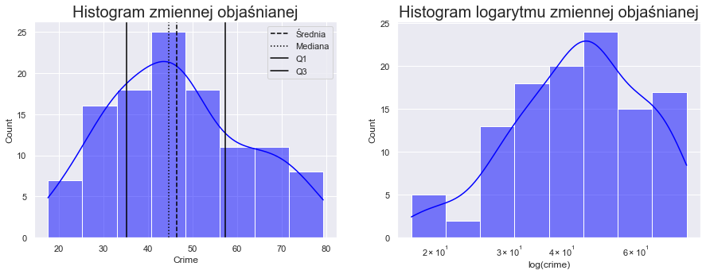

```python
fig, (axes) = plt.subplots(1, 2, figsize=(15,5), squeeze=False)

a = sns.histplot(data=dane, x='Crime', kde=True, ax=axes[0][0], color='blue')
statystyki_wykres(dane['Crime'], a)
axes[0][0].set_title('Histogram zmiennej objaśnianej', fontdict={'fontsize':20})

b = sns.histplot(data=dane, x='Crime', kde=True, log_scale=True,ax=axes[0][1], color='blue')
axes[0][1].set_title('Histogram logarytmu zmiennej objaśnianej', fontdict={'fontsize':20})
b.set(xlabel='log(crime)')

plt.show()
```

Histogram 1 - Lekka asymetria prawostronna (średnia większa od mediany). Jest to więc rozkład lognormalny, więc logarytmujemy zmienną crime i otrzymujemy Histogram 2 o rozkładzie zbliżonym do normalnego.

##### Wykres pudełkowy zmiennej objaśnianej

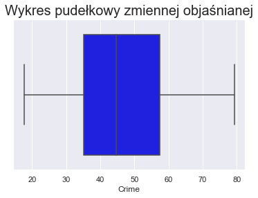

```python
sns.boxplot(x=dane['Crime'], color='blue')

plt.title('Wykres pudełkowy zmiennej objaśnianej', fontdict={'fontsize':20})

plt.show()
```

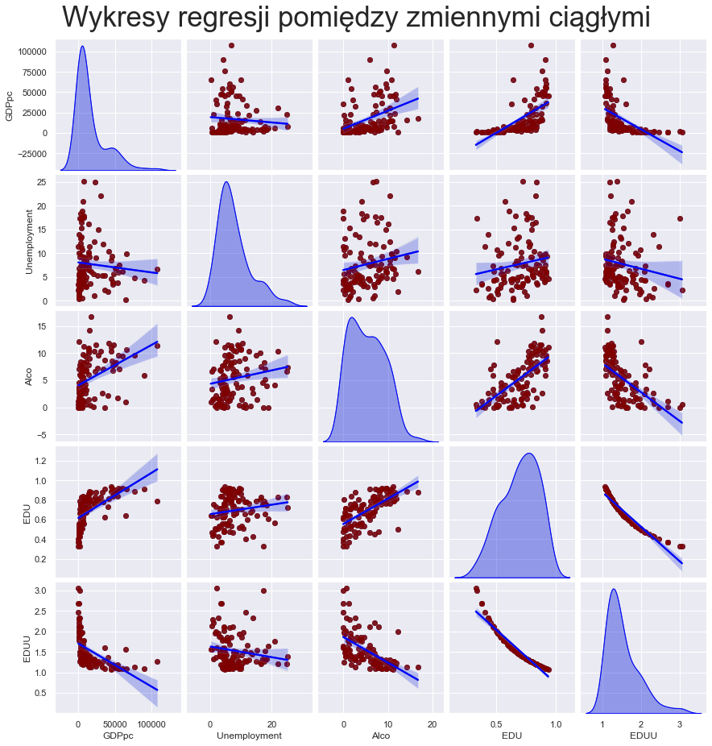

```python
a = sns.pairplot(dane[dane.columns[[1, 2, 3, 4, 10]]], diag_kind='kde', kind='reg')

a.fig.suptitle('Wykresy regresji pomiędzy zmiennymi ciągłymi', y=1.03, size=35)
a.map_upper(sns.regplot, scatter_kws={"color": "maroon"}, line_kws={"color": "blue"})
a.map_lower(sns.regplot, scatter_kws={"color": "maroon"}, line_kws={"color": "blue"})
a.map_diag(sns.kdeplot, color='blue', fill="True")

plt.show()
```

# Zmienna alco

##### Wykresy zmiennej alkohol

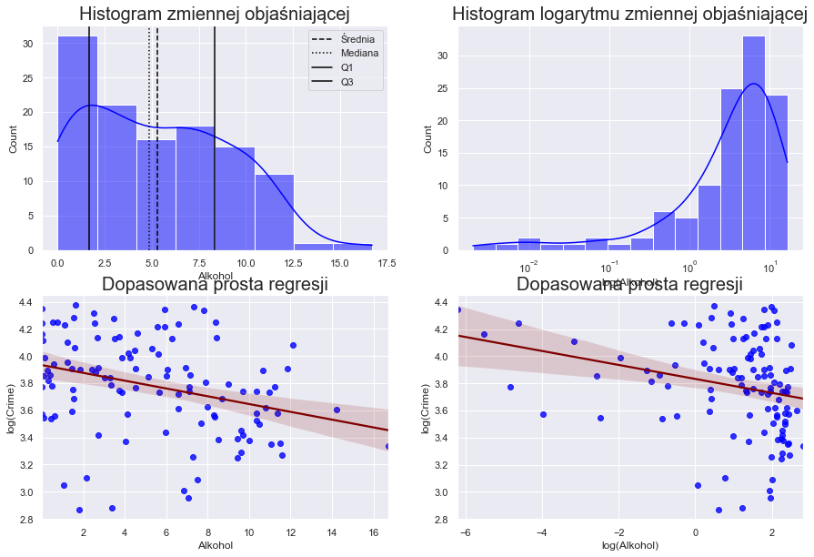

```python
fig, (ax1, ax2) = plt.subplots(2, 2, figsize=(15,10), squeeze=False)

a = sns.histplot(x=dane['Alco'], kde=True, ax=ax1[0], color='blue')
a.set_title('Histogram zmiennej objaśniającej', fontdict={'fontsize':20})
a.set(xlabel='Alkohol')
statystyki_wykres(dane.Alco, a)

b = sns.histplot(x=dane['Alco'], kde=True, log_scale=True, ax=ax1[1], color='blue')
b.set_title('Histogram logarytmu zmiennej objaśniającej', fontdict={'fontsize':20})
b.set(xlabel='log(Alkohol)')

c = sns.regplot(data=dane, x=dane['Alco'], y=np.log(dane['Crime']), ax=ax2[0], color='blue', line_kws={"color": "maroon"})
c.set_title('Dopasowana prosta regresji', fontdict={'fontsize':20})
c.set(xlabel='Alkohol', ylabel='log(Crime)')

d = sns.regplot(data=dane, x=np.log(dane['Alco']), y=np.log(dane['Crime']), ax=ax2[1], color='blue',line_kws={"color": "maroon"})
d.set_title('Dopasowana prosta regresji', fontdict={'fontsize':20})
d.set(xlabel='log(Alkohol)', ylabel='log(Crime)')

plt.show()
```

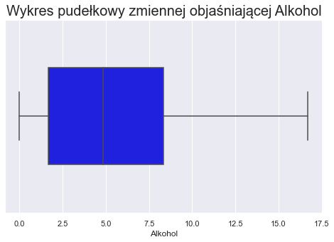

```python
plt.rc('figure', figsize = (8,5))

x = sns.boxplot(x=dane['Alco'], width=0.5, color='blue')
x.set_title('Wykres pudełkowy zmiennej objaśniającej Alkohol', fontdict={'fontsize':20})
x.set(xlabel='Alkohol')

plt.show()
```

Obserwując rozkład zmiennej Alkohol oraz wykres pudełkowy możemy zauważyć, że jest on prawostronnie asymetryczny, jednak asymetria ta nie jest na tyle znacząca aby decydować się na przekształcenie zmiennej. Obserwując wykres punktowy można zauważyć, że zależność między logarytmem zmiennej objaśnianej i nieprzekształconej zmiennej Alkohol bardziej przypomina zależność liniową, która dodatkowo wskazuje na ujemny trend. Z tego powodu zmienna Alkohol nie została poddana żadnej transformacji.

# Zmienna bezrobocie

##### Wykresy zmiennej bezrobocie

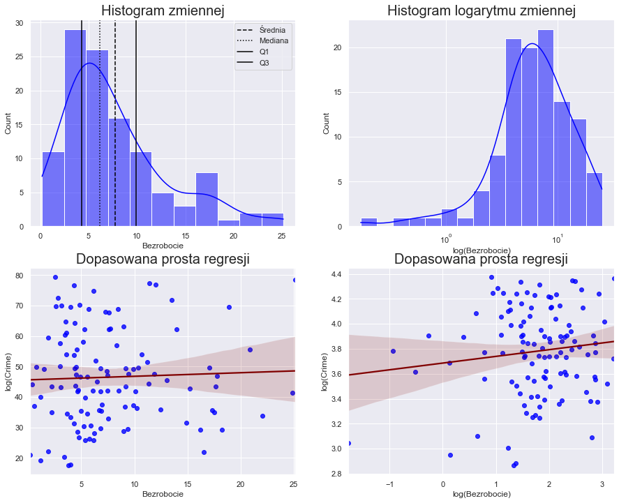

```python
fig, (ax1, ax2) = plt.subplots(2, 2, figsize=(15,12), squeeze=False)

a = sns.histplot(x=dane['Unemployment'], kde=True, ax=ax1[0],  color='blue')
a.set_title('Histogram zmiennej', fontdict={'fontsize':20})
a.set(xlabel='Bezrobocie')
statystyki_wykres(dane.Unemployment, a)

b = sns.histplot(x=dane['Unemployment'], kde=True, log_scale=True, ax=ax1[1],  color='blue')
b.set_title('Histogram logarytmu zmiennej', fontdict={'fontsize':20})
b.set(xlabel='log(Bezrobocie)')

c = sns.regplot(data=dane, x=dane['Unemployment'], y=dane['Crime'], ax=ax2[0], color='blue',line_kws={"color": "maroon"})
c.set_title('Dopasowana prosta regresji', fontdict={'fontsize':20})
c.set(xlabel='Bezrobocie', ylabel='log(Crime)')

d = sns.regplot(data=dane, x=np.log(dane['Unemployment']), y=np.log(dane['Crime']), ax=ax2[1], color='blue',line_kws={"color": "maroon"})
d.set_title('Dopasowana prosta regresji', fontdict={'fontsize':20})
d.set(xlabel='log(Bezrobocie)', ylabel='log(Crime)')

plt.show()
```

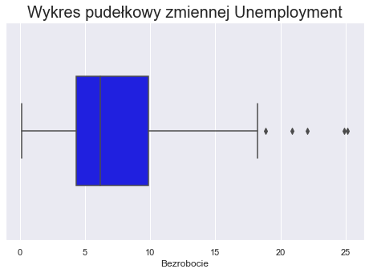

```python
x = sns.boxplot(x=dane['Unemployment'],  width=0.5,  color='blue')
x.set_title('Wykres pudełkowy zmiennej Unemployment', fontdict={'fontsize':20})
x.set(xlabel='Bezrobocie')

plt.show()
```

Obserwując rozkład zmiennej Bezrobocie oraz wykres pudełkowy możemy zauważyć, że jest ona prawostronnie asymetryczna, jednak ponownie ta asymetria nie jest za bardzo znacząca. Notmiast badając wykresy punktowe można ponownie zauważyć, że wykres przypomina bardziej liniowy w przypadku, gdy zmienna objaśniająca nie jest poddana transformacji. Stąd decyzja o nie przekształcaniu zmiennej Bezrobocie. Warto także zwrócić uwagę na wyniki odstające, które mogą negatywnie wpływać na badanie.

# Zmienna PKB per capita

##### Wykresy zmiennej PKB per capita

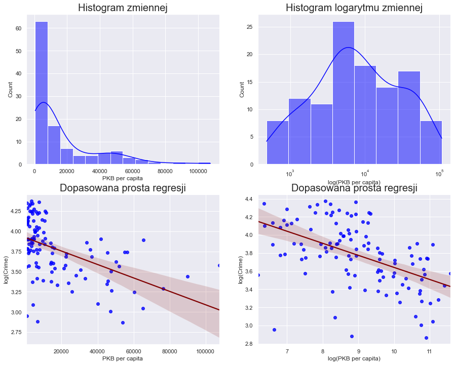

```python
fig, (ax1, ax2) = plt.subplots(2, 2, figsize=(15,12), squeeze=False)

a = sns.histplot(x=dane['GDPpc'], kde=True, ax=ax1[0], color='blue')
a.set_title('Histogram zmiennej', fontdict={'fontsize':20})
a.set(xlabel='PKB per capita')

b = sns.histplot(x=dane['GDPpc'], kde=True, log_scale=True, ax=ax1[1], color='blue')
b.set_title('Histogram logarytmu zmiennej', fontdict={'fontsize':20})
b.set(xlabel='log(PKB per capita)')

c = sns.regplot(data=dane, x=dane['GDPpc'], y=np.log(dane['Crime']), ax=ax2[0], color='blue',line_kws={"color": "maroon"})
c.set_title('Dopasowana prosta regresji', fontdict={'fontsize':20})
c.set(xlabel='PKB per capita', ylabel='log(Crime)')

d = sns.regplot(data=dane, x=np.log(dane['GDPpc']), y=np.log(dane['Crime']), ax=ax2[1], color='blue',line_kws={"color": "maroon"})
d.set_title('Dopasowana prosta regresji', fontdict={'fontsize':20})
d.set(xlabel='log(PKB per capita)', ylabel='log(Crime)')

plt.show()
```

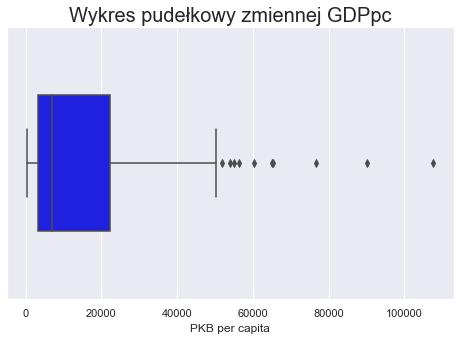

```python
x = sns.boxplot(x=dane['GDPpc'],  width=0.5, color='blue')
x.set_title('Wykres pudełkowy zmiennej GDPpc', fontdict={'fontsize':20})
x.set(xlabel='PKB per capita')

plt.show()
```

Obserwując rozkład zmiennej GDPpc oraz wykres pudełkowy można zauważyć, że jest ona zdecydowanie prawostronnie asymetryczna. Dodatkowo porównując wykresy punktowe można zauważyć, że w przypadku zlogarytmowanej zmiennej objaśniającej, wykres w większym stopniu przypomina liniowy. Stąd decyzja o użyciu przekształconej zmiennej. Ponownie warto zwrócić uwagę na dużą ilość obserwacji odstających, które mogą negatywnie wpływać na wyniki badania.

# Zmienna EDU

##### Wykresy zmiennej EDU

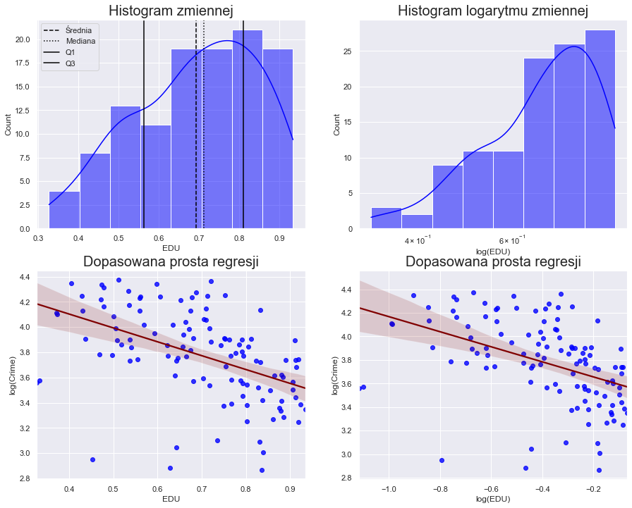

```python
fig, (ax1, ax2) = plt.subplots(2, 2, figsize=(15,12), squeeze=False)

a = sns.histplot(x=dane['EDU'], kde=True, ax=ax1[0], color='blue')
a.set_title('Histogram zmiennej', fontdict={'fontsize':20})
a.set(xlabel='EDU')

statystyki_wykres(dane.EDU, ax1[0])

b = sns.histplot(x=dane['EDU'], kde=True, log_scale=True, ax=ax1[1], color='blue')
b.set_title('Histogram logarytmu zmiennej', fontdict={'fontsize':20})
b.set(xlabel='log(EDU)')

c = sns.regplot(data=dane, x=dane['EDU'], y=np.log(dane['Crime']), ax=ax2[0], color='blue',line_kws={"color": "maroon"})
c.set_title('Dopasowana prosta regresji', fontdict={'fontsize':20})
c.set(xlabel='EDU', ylabel='log(Crime)')

d = sns.regplot(data=dane, x=np.log(dane['EDU']), y=np.log(dane['Crime']), ax=ax2[1], color='blue', line_kws={"color": "maroon"})
d.set_title('Dopasowana prosta regresji', fontdict={'fontsize':20})
d.set(xlabel='log(EDU)', ylabel='log(Crime)')

plt.show()
```

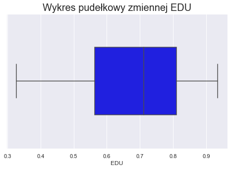

```python
x = sns.boxplot(x=dane['EDU'], width=0.5, color='blue')
x.set_title('Wykres pudełkowy zmiennej EDU', fontdict={'fontsize':20})
x.set(xlabel='EDU')

plt.show()
```

Obserwując rozkład zmiennej EDU można zauważyć, że jest on lewostronnie asymetryczny. Natomiast rozkład logarytmu zmiennej EDU nie poprawia tego problemu. Dodatkowo badając wykresy punktowe można zauważyć wysokie podobieństwop między nimi. Stąd decyzja o nie przekształcaniu zmiennej. Wykres pudełkowy także wskazuje na asymetrię lewostronną. Badając zależność między zmienną EDU i zlogarytmowaną zmienną crime możemy zauważyć ujemnie nachyloną linię trendu.

# Zmienna populacja

##### Wykresy zmiennej populacja

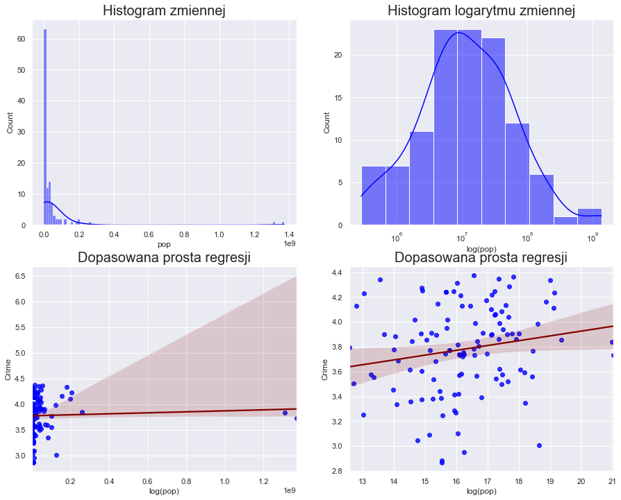

```python
fig, (ax1, ax2) = plt.subplots(2, 2, figsize=(15,12), squeeze=False)

a = sns.histplot(x=dane['pop'], kde=True, ax=ax1[0], color='blue')
a.set_title('Histogram zmiennej', fontdict={'fontsize':20})
a.set(xlabel='pop')

# statystyki_wykres(dane['pop'], ax1[0]) tutaj nie używam fukncji ponieważ jest ona nieczytelna na wykresie

b = sns.histplot(x=dane['pop'], kde=True, log_scale=True, ax=ax1[1], color='blue')
b.set_title('Histogram logarytmu zmiennej', fontdict={'fontsize':20})
b.set(xlabel='log(pop)')

c = sns.regplot(data=dane, x=dane['pop'], y=np.log(dane['Crime']), ax=ax2[0], color='blue', line_kws={"color": "maroon"})
c.set_title('Dopasowana prosta regresji', fontdict={'fontsize':20})
c.set(xlabel='log(pop)')

d = sns.regplot(data=dane, x=np.log(dane['pop']), y=np.log(dane['Crime']), ax=ax2[1], color='blue',line_kws={"color": "maroon"})
d.set_title('Dopasowana prosta regresji', fontdict={'fontsize':20})
d.set(xlabel='log(pop)')

plt.show()
```

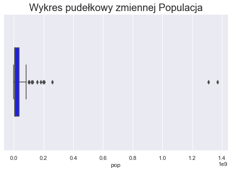

```python
x = sns.boxplot(x=dane['pop'], width=0.5, color='blue')
x.set_title('Wykres pudełkowy zmiennej Populacja', fontdict={'fontsize':20})
x.set(xlabel='pop')

plt.show()
```

Obserwując rozkład zmiennej Populacja można zauważyć, że jest on zdecydowanie prawostronnie asymetryczny. Natomiast rozkład logarytmu zmiennej Populacja bardziej przypomina rozkład normalny. Dodatkowo badając wykresy punktowe można zauważyć, że wykres zawierający logarytm zmiennej Populacja w dużo większym stopniu przypomina wykres liniowy. Stąd decyzja o przekształcaniu zmiennej. Wykres pudełkowy także wskazuje na asymetrię prawostronną. Warto zwrócić uwagę na dużą ilość obserwacji odstających, które mogą negatywnie wpływać na wyniki badania.

# Wykresy zmiennych binarnych

##### Wykres kołowy zmiennej Kontynent

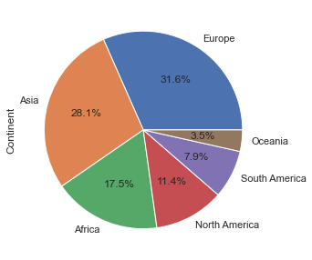

```python
dane['Continent'].value_counts().plot.pie(autopct="%.1f%%")

plt.show()
```

##### Wykres kołowy zmiennej Kara Śmierci

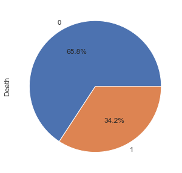

```python
dane['Death'].value_counts().plot.pie(autopct="%.1f%%")

plt.show()
```

##### Wykres kołowy zmiennej dostęp do broni

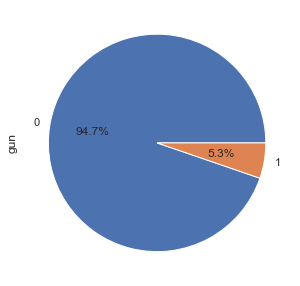

```python
dane['gun'].value_counts().plot.pie(autopct="%.1f%%")

plt.show()
```

Wykresy kołowe przedstawiają jaką część wszystkich obserwacji stanowią poszczególne obserwacje.

- Na 1 wykresie kraje zostały podzielone według kontynentów;
- Na 2 wykresie według tego czy kara śmierci jest stosowana w danym kraju;
- Na 3 wykresie według tego czy dostęp do broni nie wymaga pozwolenia.

Analizując bazę danych warto zwrócić uwagę na przeważającą liczbę krajów z Europy i Azji, które łącznie stanowią prawie 60% wszystkich badanych krajów. Warto dodać, że w badanej próbie znajduje się także niewielki odsetek krajów (5.3%), w których istnieje powszechne prawo dostępu do broni - nie wymaga zezwolenia. Te nierówności mogą zaburzać wyniki przeprowadzonego doświadczenia. Kara śmierci za to jest stosowana w 34% badanych krajów.

# Korelacja pomiędzy zmiennymi EDU a GDPpc

##### Współczynnik korelacji Pearsona

```python
print(np.corrcoef(dane['EDU'], dane['GDPpc'])[1][0])
```

```
0.631245720354345
```

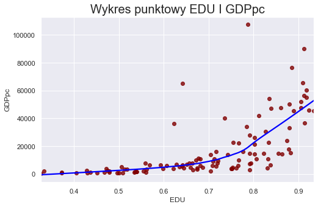

```python
x = sns.regplot(x=dane['EDU'], y=dane['GDPpc'], color='blue', lowess=True, scatter_kws={"color": "maroon"})
x.set_title('Wykres punktowy EDU I GDPpc', fontdict={'fontsize':20})
x.set(xlabel='EDU', ylabel='GDPpc')

plt.show()
```

Analizując wykres można zauważyć, że zależność GDPpc od EDU przypomina funkcję wykładniczą. Dodatkowo korelacja między tymi zmiennymi wynosi ponad 60%. Powodem tego jest sposób wyliczania wskaźnika edukacji, który w dużej mierze zależy od GDPpc. Zdecydowaliśmy się, więc, usunąć zmienną GDPpc z dalszych rozważań, ponieważ jej wpływ w dużej mierze jest reprezentowany przez wskaźnik edukacji.

# Selekcja zmiennych objaśniających do modelu

```python
import statsmodels.api as sm
import statsmodels.formula.api as smf
from stargazer.stargazer import Stargazer
```

# Model 1

```python
rownanie_1 = 'np.log(Crime) ~ Unemployment + Alco + EDU + EDUU + np.log(pop) + C(Death) + C(gun) + C(Asia)+C(South_America) + C(North_America) + C(Africa) + C(Oceania)'
m1 = smf.ols(rownanie_1, dane).fit()

display(m1.summary())
```

OLS Regression Results

| Dep. Variable: | np.log(Crime) | R-squared: | 0.454 |
| --- | --- | --- | --- |
| Model: | OLS | Adj. R-squared: | 0.389 |
| Method: | Least Squares | F-statistic: | 6.985 |
| Date: | Sun, 07 Feb 2021 | Prob (F-statistic): | 4.41e-09 |
| Time: | 22:35:48 | Log-Likelihood: | -8.7374 |
| No. Observations: | 114 | AIC: | 43.47 |
| Df Residuals: | 101 | BIC: | 79.05 |
| Df Model: | 12 |  |  |
| Covariance Type: | nonrobust |  |  |

|  | coef | std err | t | P>\|t\| | [0.025 | 0.975] |
| --- | --- | --- | --- | --- | --- | --- |
| Intercept | 5.8534 | 0.934 | 6.267 | 0.000 | 4.001 | 7.706 |
| C(Death)[T.1] | 0.0323 | 0.066 | 0.490 | 0.625 | -0.098 | 0.163 |
| C(gun)[T.1] | -0.0463 | 0.137 | -0.338 | 0.736 | -0.318 | 0.225 |
| C(Asia)[T.1] | -0.0491 | 0.127 | -0.385 | 0.701 | -0.302 | 0.204 |
| C(South_America)[T.1] | 0.3082 | 0.124 | 2.494 | 0.014 | 0.063 | 0.553 |
| C(North_America)[T.1] | 0.2991 | 0.119 | 2.512 | 0.014 | 0.063 | 0.535 |
| C(Africa)[T.1] | 0.0462 | 0.120 | 0.384 | 0.702 | -0.193 | 0.285 |
| C(Oceania)[T.1] | 0.3599 | 0.158 | 2.283 | 0.025 | 0.047 | 0.672 |
| Unemployment | 0.0111 | 0.006 | 1.927 | 0.057 | -0.000 | 0.022 |
| Alco | -0.0010 | 0.012 | -0.085 | 0.933 | -0.024 | 0.022 |
| EDU | -2.5741 | 0.757 | -3.401 | 0.001 | -4.076 | -1.073 |
| EDUU | -0.6110 | 0.251 | -2.438 | 0.017 | -1.108 | -0.114 |
| np.log(pop) | 0.0304 | 0.018 | 1.722 | 0.088 | -0.005 | 0.065 |

| Omnibus: | 15.568 | Durbin-Watson: | 0.752 |
| --- | --- | --- | --- |
| Prob(Omnibus): | 0.000 | Jarque-Bera (JB): | 22.209 |
| Skew: | -0.679 | Prob(JB): | 1.50e-05 |
| Kurtosis: | 4.682 | Cond. No. | 889. |

Notes:  
[1] Standard Errors assume that the covariance matrix of the errors is correctly specified.

Test hipotezy łącznej o nieistotności zmiennych:

(Alco = 0), (C(gun)[T.1] = 0), (C(Death)[T.1] =0), (C(Asia)[T.1] = 0), (C(Africa)[T.1] = 0), (np.log(pop) = 0)

```python
hip6 = '(Alco = 0), (C(gun)[T.1] = 0), (C(Death)[T.1] =0), (C(Asia)[T.1] = 0), (C(Africa)[T.1] = 0), (np.log(pop) = 0)'
f_test6 = m1.f_test(hip6)
display(f_test6)
```

```
<class 'statsmodels.stats.contrast.ContrastResults'>
<F test: F=array([[0.7135775]]), p=0.6394602725613692, df_denom=101, df_num=6>
```

##### Ponieważ hipoteza o łącznej nieistotności zmiennych Alco, Gun, Asia, Africa, log(pop) jest prawdziwa (p-value = 0.64 > 0.05), usuwam te zmienne z modelu.

# Model 2

```python
rownanie_2 = 'np.log(Crime) ~ Unemployment + EDU + C(South_America) + C(North_America) + C(Oceania) + EDUU'
m2 = smf.ols(rownanie_2, dane).fit()

display(m2.summary())
```

OLS Regression Results

| Dep. Variable: | np.log(Crime) | R-squared: | 0.430 |
| --- | --- | --- | --- |
| Model: | OLS | Adj. R-squared: | 0.398 |
| Method: | Least Squares | F-statistic: | 13.47 |
| Date: | Sun, 07 Feb 2021 | Prob (F-statistic): | 2.47e-11 |
| Time: | 22:35:48 | Log-Likelihood: | -11.104 |
| No. Observations: | 114 | AIC: | 36.21 |
| Df Residuals: | 107 | BIC: | 55.36 |
| Df Model: | 6 |  |  |
| Covariance Type: | nonrobust |  |  |

|  | coef | std err | t | P>\|t\| | [0.025 | 0.975] |
| --- | --- | --- | --- | --- | --- | --- |
| Intercept | 6.2238 | 0.778 | 7.999 | 0.000 | 4.681 | 7.766 |
| C(South_America)[T.1] | 0.3307 | 0.098 | 3.369 | 0.001 | 0.136 | 0.525 |
| C(North_America)[T.1] | 0.2703 | 0.084 | 3.232 | 0.002 | 0.104 | 0.436 |
| C(Oceania)[T.1] | 0.3378 | 0.143 | 2.355 | 0.020 | 0.053 | 0.622 |
| Unemployment | 0.0118 | 0.005 | 2.383 | 0.019 | 0.002 | 0.022 |
| EDU | -2.5591 | 0.625 | -4.098 | 0.000 | -3.797 | -1.321 |
| EDUU | -0.5416 | 0.228 | -2.377 | 0.019 | -0.993 | -0.090 |

| Omnibus: | 17.688 | Durbin-Watson: | 0.707 |
| --- | --- | --- | --- |
| Prob(Omnibus): | 0.000 | Jarque-Bera (JB): | 25.027 |
| Skew: | -0.773 | Prob(JB): | 3.68e-06 |
| Kurtosis: | 4.697 | Cond. No. | 376. |

Notes:  
[1] Standard Errors assume that the covariance matrix of the errors is correctly specified.

# Porównanie pierwotnej i ostatecznej wersji modelu

```python
display(Stargazer([m1, m2]))
```

|  | *Dependent variable:np.log(Crime)* |  |
| --- | --- | --- |
|  | (1) | (2) |
| Alco | -0.001 |  |
|  | (0.012) |  |
| C(Africa)[T.1] | 0.046 |  |
|  | (0.120) |  |
| C(Asia)[T.1] | -0.049 |  |
|  | (0.127) |  |
| C(Death)[T.1] | 0.032 |  |
|  | (0.066) |  |
| C(North_America)[T.1] | 0.299** | 0.270*** |
|  | (0.119) | (0.084) |
| C(Oceania)[T.1] | 0.360** | 0.338** |
|  | (0.158) | (0.143) |
| C(South_America)[T.1] | 0.308** | 0.331*** |
|  | (0.124) | (0.098) |
| C(gun)[T.1] | -0.046 |  |
|  | (0.137) |  |
| EDU | -2.574*** | -2.559*** |
|  | (0.757) | (0.625) |
| EDUU | -0.611** | -0.542** |
|  | (0.251) | (0.228) |
| Intercept | 5.853*** | 6.224*** |
|  | (0.934) | (0.778) |
| Unemployment | 0.011* | 0.012** |
|  | (0.006) | (0.005) |
| np.log(pop) | 0.030* |  |
|  | (0.018) |  |
| Observations | 114 | 114 |
| R<sup>2</sup> | 0.454 | 0.430 |
| Adjusted R<sup>2</sup> | 0.389 | 0.398 |
| Residual Std. Error | 0.278 (df=101) | 0.275 (df=107) |
| F Statistic | 6.985*** (df=12; 101) | 13.473*** (df=6; 107) |
| Note: | *p<0.1; **p<0.05; ***p<0.01 |  |

# Autokorelacja reszt w modelu

```python
print ("\033[1m" + 'Wartości dopasowane:\n' + "\033[0m", m2.fittedvalues)

print ("\033[1m" + '\nReszty:     \n' + "\033[0m" , m2.resid)
```

```
Wartości dopasowane:
 Country
Guatemala       4.155741
South Africa    3.927101
Afghanistan     3.985053
Guyana          4.260775
Nigeria         3.919297
                  ...
Qatar           3.739292
Japan           3.471489
Rwanda          3.882452
Turkmenistan    3.801147
Singapore       3.483254
Length: 114, dtype: float64

Reszty:
 Country
Guatemala       0.218002
South Africa    0.435233
Afghanistan     0.363158
Guyana          0.081471
Nigeria         0.419300
                  ...
Qatar          -0.692867
Japan          -0.463828
Rwanda         -0.929627
Turkmenistan   -0.918583
Singapore      -0.615923
Length: 114, dtype: float64
```

```python
from scipy.stats import spearmanr
```

```python
coef, p_value = spearmanr(m2.fittedvalues, m2.resid)
print('Współczynnik korelacji Spearmana wynosi: %.3f' % coef)
alpha = 0.05
if p_value > alpha:
    print('Zmienne są nieskorelowane (brak podstaw do odrzucenia H0) - p_value = %.3f' % p_value)
else:
    print('Samples are correlated (reject H0) p_value = %.3f' % p_value)
```

```
Współczynnik korelacji Spearmana wynosi: -0.001
Zmienne są nieskorelowane (brak podstaw do odrzucenia H0) - p_value = 0.991
```

## Test Breucha-Godfreya

- H0 -- brak autokorelacji reszt
- H1 -- występuje autokorelacja reszt

```python
import statsmodels.stats.api as sms
```

```python
test7_4 = sms.acorr_breusch_godfrey(m2, nlags=None)
names1 = ['lagrange multiplier stat', 'p-value', 'fvalue', 'f_pvalue']
test7_4
display(list(zip(names1, test7_4)))
```

```
[('lagrange multiplier stat', 83.35472812924661),
 ('p-value', 9.420034702262783e-13),
 ('fvalue', 21.533227065922773),
 ('f_pvalue', 4.704061632100403e-22)]
```

##### Obie wartości p-value z testu Breucha-Godfreya są biskie zeru, więc odrzucamy H0 na rzecz H1 mówiącej o autokorelacji składnika losowego.

Dodaje więc macież odporną HAC - Newey-West odporna zarówno na na heteroskedastyczność oraz autokorelację reszt.

```python
m2HAC= smf.ols(formula = 'np.log(Crime) ~ Unemployment + EDU + EDUU + C(South_America) + C(North_America) + C(Oceania)', data = dane).fit(cov_type ='HAC', cov_kwds = {'maxlags':1})

display(m2HAC.summary())
```

OLS Regression Results

| Dep. Variable: | np.log(Crime) | R-squared: | 0.430 |
| --- | --- | --- | --- |
| Model: | OLS | Adj. R-squared: | 0.398 |
| Method: | Least Squares | F-statistic: | 21.14 |
| Date: | Sun, 07 Feb 2021 | Prob (F-statistic): | 3.13e-16 |
| Time: | 22:35:48 | Log-Likelihood: | -11.104 |
| No. Observations: | 114 | AIC: | 36.21 |
| Df Residuals: | 107 | BIC: | 55.36 |
| Df Model: | 6 |  |  |
| Covariance Type: | HAC |  |  |

|  | coef | std err | z | P>\|z\| | [0.025 | 0.975] |
| --- | --- | --- | --- | --- | --- | --- |
| Intercept | 6.2238 | 0.748 | 8.323 | 0.000 | 4.758 | 7.689 |
| C(South_America)[T.1] | 0.3307 | 0.063 | 5.231 | 0.000 | 0.207 | 0.455 |
| C(North_America)[T.1] | 0.2703 | 0.059 | 4.565 | 0.000 | 0.154 | 0.386 |
| C(Oceania)[T.1] | 0.3378 | 0.050 | 6.772 | 0.000 | 0.240 | 0.436 |
| Unemployment | 0.0118 | 0.006 | 2.062 | 0.039 | 0.001 | 0.023 |
| EDU | -2.5591 | 0.568 | -4.502 | 0.000 | -3.673 | -1.445 |
| EDUU | -0.5416 | 0.220 | -2.462 | 0.014 | -0.973 | -0.110 |

| Omnibus: | 17.688 | Durbin-Watson: | 0.707 |
| --- | --- | --- | --- |
| Prob(Omnibus): | 0.000 | Jarque-Bera (JB): | 25.027 |
| Skew: | -0.773 | Prob(JB): | 3.68e-06 |
| Kurtosis: | 4.697 | Cond. No. | 376. |

Notes:  
[1] Standard Errors are heteroscedasticity and autocorrelation robust (HAC) using 1 lags and without small sample correction

### Porównanie modeli bez macierzy HAC oraz z macierzą

```python
display(Stargazer([m2, m2HAC]))
```

|  | *Dependent variable:np.log(Crime)* |  |
| --- | --- | --- |
|  | (1) | (2) |
| C(North_America)[T.1] | 0.270*** | 0.270*** |
|  | (0.084) | (0.059) |
| C(Oceania)[T.1] | 0.338** | 0.338*** |
|  | (0.143) | (0.050) |
| C(South_America)[T.1] | 0.331*** | 0.331*** |
|  | (0.098) | (0.063) |
| EDU | -2.559*** | -2.559*** |
|  | (0.625) | (0.568) |
| EDUU | -0.542** | -0.542** |
|  | (0.228) | (0.220) |
| Intercept | 6.224*** | 6.224*** |
|  | (0.778) | (0.748) |
| Unemployment | 0.012** | 0.012** |
|  | (0.005) | (0.006) |
| Observations | 114 | 114 |
| R<sup>2</sup> | 0.430 | 0.430 |
| Adjusted R<sup>2</sup> | 0.398 | 0.398 |
| Residual Std. Error | 0.275 (df=107) | 0.275 (df=107) |
| F Statistic | 13.473*** (df=6; 107) | 21.142*** (df=6; 107) |
| Note: | *p<0.1; **p<0.05; ***p<0.01 |  |

# Normalność rozkładu reszt

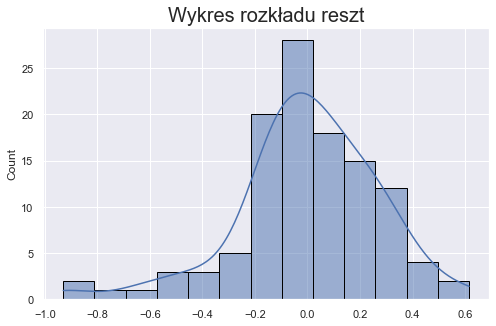

```python
plt.rc('figure', figsize=(8,5))

x = sns.histplot(m2.resid, log_scale=False, kde=True, edgecolor='black')
x.set_title('Wykres rozkładu reszt', fontdict={'fontsize':20})

plt.show()
```

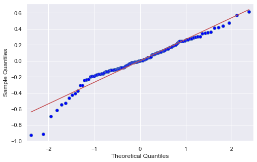

```python
sm.qqplot(m2.resid, line = 'r')

plt.show()
```

### Test Jarque-Bera

```python
test2_1 = sms.jarque_bera(m2.resid)
test2_1
print(f'Współczynnik skośności = {test2_1[2]}')
print(f'Współczynnik kurtuozy = {test2_1[3]}')
print(f'Statystyka Jarque-Bera = {test2_1[0]}')
print(f'p-value statystyki Jarque-Bera = {test2_1[1]}')
```

```
Współczynnik skośności = -0.7728914477004755
Współczynnik kurtuozy = 4.6968662207759815
Statystyka Jarque-Bera = 25.026798721892366
p-value statystyki Jarque-Bera = 3.67705145886814e-06
```

##### Na podstawie powyższych obliczeń możemy odrzucić H0 mówiącą o normalności rozkładu reszt (p-value < 0.05).¶

# Poprawność formy funkcyjnej

### Test RESET

- H0 -- poprawna postać funkcyjna modelu
- H1 -- brak liniowej postaci funkcyjnej modelu

```python
import statsmodels.api as sm
```

```python
display(sms.linear_reset(m2, power=3, use_f=True))
```

```
<class 'statsmodels.stats.contrast.ContrastResults'>
<F test: F=array([[0.96850749]]), p=0.3830144867718617, df_denom=105, df_num=2>
```

##### p-value = 0.3830, brak podstaw do odrzucenia H0 mówiącej o poprawnej postaci fukncyjnej modelu

### Test Chowa

- H0 - parametry są takie same w podpróbkach
- H1 - parametry różnią się w podpróbkach

```python
m2ca = 'np.log(Crime) ~ Unemployment + EDU + EDUU + C(South_America) + C(North_America) + C(Oceania)'
m2ca = smf.ols(m2ca, dane[dane.Death==1]).fit()

m2cb = 'np.log(Crime) ~ Unemployment + EDU + EDUU + C(South_America) + C(North_America) + C(Oceania)'
m2cb = smf.ols(m2cb, dane[dane.Death==0]).fit()
```

```python
def f_chow(model, model_a, model_b, alfa=0.05):
    '''Test Chowa dla dwóch populacji, gdzie:

    model - model pierwotny
    model_a - pierwsza z populacji
    model_b - druga z populacji
    alfa - poziom istotności

    Funkcja zwraca obiekt tuple zawierający:
     - wartość statystyki F
     - wartość krytyczna F
     - p-value testu'''

    K = len(model.params)
    licznik = (model.ssr - model_a.ssr - model_b.ssr) / K
    mianownik = (model_a.ssr + model_b.ssr)/(model.nobs - 2*K)

    F = licznik / mianownik

    krytyczna = scipy.stats.f.ppf(q=1-alfa, dfn=K, dfd=(model.nobs - 2*K))

    p_value = 1 - scipy.stats.f.cdf(F, dfn=K, dfd=(model.nobs - 2*K))
    return F, krytyczna, p_value
```

```python
x = f_chow(m2, m2ca, m2cb)
print("\033[1m" + 'Test Chowa:' + "\033[0m" +
f'''\n\nWartość statysyki F: {x[0]}
Wartość krytyczna F: {x[1]}
p-value: {x[2]}''')
```

```
Test Chowa:

Wartość statysyki F: 1.623444956769288
Wartość krytyczna F: 2.102513294552775
p-value: 0.1373936330753187
```

##### p-value testu Chowa wynosi 0.1374, więc nie mamy podstaw do odrzucenia H0 - nie występują istotne różnice oszacowań parametrów w podgrupach.

# Homoskedastyczność

- H0 - występuje homoskedastyczność
- H1 - występuje heteroskedastyczność

### TEST BREUSCHA-PAGANA

```python
test7_2 = sms.het_breuschpagan(m2.resid, m2.model.exog)
test7_2
display(list(zip(names1, test7_2)))
```

```
[('lagrange multiplier stat', 8.265389624307907),
 ('p-value', 0.21929782714441698),
 ('fvalue', 1.3940510848474668),
 ('f_pvalue', 0.2236644478415563)]
```

### Test WHITE'A

```python
test2_3 = sms.het_white(m2.resid, m2.model.exog)
test2_3
display(list(zip(names1, test2_3)))
```

```
[('lagrange multiplier stat', 15.861421500751305),
 ('p-value', 0.7251833664380409),
 ('fvalue', 0.7515455298657928),
 ('f_pvalue', 0.7624958905012879)]
```

# Dźwignie, standaryzowane reszty oraz odległości Cook'a.

```python
import statsmodels
```

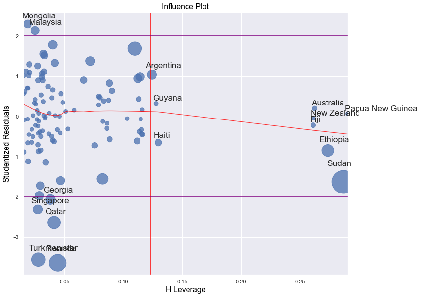

```python
plt.rc('figure', figsize = (12,10))
sm.graphics.influence_plot(m2, criterion = 'Cooks')
sns.regplot(m2.get_influence().hat_matrix_diag, m2.get_influence().resid_studentized_internal,
              scatter=False,
              ci=False,
              lowess=True,
              line_kws={'color': 'red', 'lw': 1.2, 'alpha': 0.8})
plt.axvline(x=2*len(m2.params)/m2.nobs, color='red')
plt.axhline(y=2, color='purple')
plt.axhline(y=-2, color='purple')
plt.show()
```

Na powyższym wykresie zostały przedstawione wartosci dzwigni oraz standaryzowanych reszt dla wszystkich obserwacji. Wielkość obserwacji zależy od odległości Cooka danej obserwacji. Powyżej górnej i poniżej dolnej fioletowej linii znajdują się obserwacje, które można uznać za nietypowe ze względu na wartość reszt. Na prawo od czerwonej pionowej linii znajdują się obserwacje nietypowe ze względu na wysoką wartość dźwigni. Czerwona linia w środku przedstawia linię trendu.

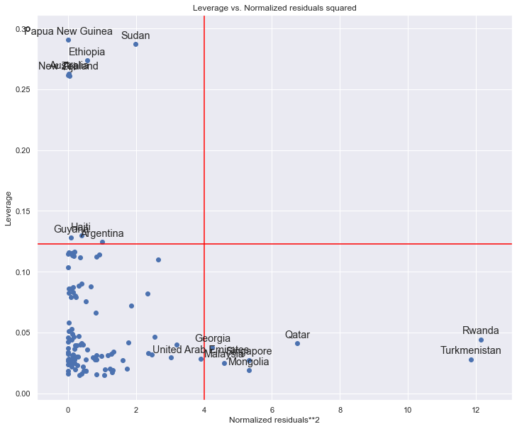

```python
plt.rc('figure', figsize = (12,10))
sm.graphics.plot_leverage_resid2(m2)
plt.axvline(x=4, color='red')
plt.axhline(y=2*len(m2.params)/m2.nobs, color='red')
plt.show()
```

Na powyższym wykresie widzimy zależność pomiędzy standaryzowanymi resztami do kwadratu a wartościami dźwigni.

### Tabela zawierająca 10 największych odległości Cooka, dźwignie i standaryzowane reszty

```python
x = statsmodels.stats.outliers_influence.OLSInfluence(m2)
a = x.summary_frame()
cook = a[['cooks_d', 'hat_diag', 'student_resid']].sort_values(by=['cooks_d'], ascending=False).head(10)
cook['Odległośći Cooka'] = cook.cooks_d
cook['Dźwignie'] = cook.hat_diag
cook['Standaryzowane reszty'] = cook.student_resid
display(cook.iloc[:,[3,4,5]])
```

| Country | Odległośći Cooka | Dźwignie | Standaryzowane reszty |
| --- | --- | --- | --- |
| Sudan | 0.150361 | 0.287066 | -1.629224 |
| Rwanda | 0.078950 | 0.044274 | -3.647106 |
| South Africa | 0.049470 | 0.109804 | 1.690008 |
| Turkmenistan | 0.046893 | 0.027866 | -3.564279 |
| Qatar | 0.040510 | 0.041162 | -2.640891 |
| Ethiopia | 0.038899 | 0.273705 | -0.848916 |
| Nicaragua | 0.030505 | 0.082218 | -1.554076 |
| Georgia | 0.023385 | 0.038021 | -2.065937 |
| Argentina | 0.021835 | 0.124322 | 1.037959 |
| Afghanistan | 0.020757 | 0.071925 | 1.374925 |